# Project Foundations for Data Science: FoodHub Data Analysis

**Marks: 60**

### Context

The number of restaurants in New York is increasing day by day. Lots of students and busy professionals rely on those restaurants due to their hectic lifestyles. Online food delivery service is a great option for them. It provides them with good food from their favorite restaurants. A food aggregator company FoodHub offers access to multiple restaurants through a single smartphone app.

The app allows the restaurants to receive a direct online order from a customer. The app assigns a delivery person from the company to pick up the order after it is confirmed by the restaurant. The delivery person then uses the map to reach the restaurant and waits for the food package. Once the food package is handed over to the delivery person, he/she confirms the pick-up in the app and travels to the customer's location to deliver the food. The delivery person confirms the drop-off in the app after delivering the food package to the customer. The customer can rate the order in the app. The food aggregator earns money by collecting a fixed margin of the delivery order from the restaurants.

### Objective

The food aggregator company has stored the data of the different orders made by the registered customers in their online portal. They want to analyze the data to get a fair idea about the demand of different restaurants which will help them in enhancing their customer experience. Suppose you are hired as a Data Scientist in this company and the Data Science team has shared some of the key questions that need to be answered. Perform the data analysis to find answers to these questions that will help the company to improve the business.

### Data Description

The data contains the different data related to a food order. The detailed data dictionary is given below.

### Data Dictionary

- order_id: Unique ID of the order
- customer_id: ID of the customer who ordered the food
- restaurant_name: Name of the restaurant
- cuisine_type: Cuisine ordered by the customer
- cost: Cost of the order
- day_of_the_week: Indicates whether the order is placed on a weekday or weekend (The weekday is from Monday to Friday and the weekend is Saturday and Sunday)
- rating: Rating given by the customer out of 5
- food_preparation_time: Time (in minutes) taken by the restaurant to prepare the food. This is calculated by taking the difference between the timestamps of the restaurant's order confirmation and the delivery person's pick-up confirmation.
- delivery_time: Time (in minutes) taken by the delivery person to deliver the food package. This is calculated by taking the difference between the timestamps of the delivery person's pick-up confirmation and drop-off information

### Let us start by importing the required libraries

```python
# import libraries for data manipulation
import numpy as np
import pandas as pd

# import libraries for data visualization
import matplotlib.pyplot as plt
import seaborn as sns
%matplotlib inline
```

### Understanding the structure of the data

```python
# read the data
df1 = pd.read_csv('foodhub_order.csv')

# make a copy of the data so that original data is not altered
df = df1.copy()

# returns the first 5 rows
df.head()
```

|  | order_id | customer_id | restaurant_name | cuisine_type | cost_of_the_order | day_of_the_week | rating | food_preparation_time | delivery_time |
| --- | --- | --- | --- | --- | --- | --- | --- | --- | --- |
| 0 | 1477147 | 337525 | Hangawi | Korean | 30.75 | Weekend | Not given | 25 | 20 |
| 1 | 1477685 | 358141 | Blue Ribbon Sushi Izakaya | Japanese | 12.08 | Weekend | Not given | 25 | 23 |
| 2 | 1477070 | 66393 | Cafe Habana | Mexican | 12.23 | Weekday | 5 | 23 | 28 |
| 3 | 1477334 | 106968 | Blue Ribbon Fried Chicken | American | 29.20 | Weekend | 3 | 25 | 15 |
| 4 | 1478249 | 76942 | Dirty Bird to Go | American | 11.59 | Weekday | 4 | 25 | 24 |

#### Observations:

The DataFrame has 9 columns as mentioned in the Data Dictionary. Data in each row corresponds to the order placed by a customer.

### **Question 1:** How many rows and columns are present in the data? [0.5 mark]

```python
# .shape tells us (rows, columns), so there are 1898 rows and 9 columns
df.shape
```

```
(1898, 9)
```

#### Observations:

There are 1898 rows and 9 columns.

### **Question 2:** What are the datatypes of the different columns in the dataset? (The info() function can be used) [0.5 mark]

```python
# Use info() to print a concise summary of the DataFrame
df.info()
```

```
<class 'pandas.core.frame.DataFrame'>
RangeIndex: 1898 entries, 0 to 1897
Data columns (total 9 columns):
 #   Column                 Non-Null Count  Dtype
---  ------                 --------------  -----
 0   order_id               1898 non-null   int64
 1   customer_id            1898 non-null   int64
 2   restaurant_name        1898 non-null   object
 3   cuisine_type           1898 non-null   object
 4   cost_of_the_order      1898 non-null   float64
 5   day_of_the_week        1898 non-null   object
 6   rating                 1898 non-null   object
 7   food_preparation_time  1898 non-null   int64
 8   delivery_time          1898 non-null   int64
dtypes: float64(1), int64(4), object(4)
memory usage: 133.6+ KB
```

#### Observations:

The following datatypes can be found for each column:

- Integer:
  - order_id
  - customer_id
  - food_preparation_time
  - delivery_time
- Float:
  - cost_of_the_order
- Object:
  - restaurant_name
  - cuisine_type
  - day_of_the_week
  - rating

It is interesting to note that rating is listed as an object instead of int or float.

### **Question 3:** Are there any missing values in the data? If yes, treat them using an appropriate method. [1 mark]

```python
# .isna() and .sum() tell us if there are any missing values and, if so, how many

df.isna().sum()
```

```
order_id                 0
customer_id              0
restaurant_name          0
cuisine_type             0
cost_of_the_order        0
day_of_the_week          0
rating                   0
food_preparation_time    0
delivery_time            0
dtype: int64
```

#### Observations:

There are no missing values for any of the columns.

### **Question 4:** Check the statistical summary of the data. What is the minimum, average, and maximum time it takes for food to be prepared once an order is placed? [2 marks]

```python
# Using .describe(), we receive the minimum (min), average (mean), and maximum (max) for numerical variables

df.describe(include='all')
```

|  | order_id | customer_id | restaurant_name | cuisine_type | cost_of_the_order | day_of_the_week | rating | food_preparation_time | delivery_time |
| --- | --- | --- | --- | --- | --- | --- | --- | --- | --- |
| count | 1.898000e+03 | 1898.000000 | 1898 | 1898 | 1898.000000 | 1898 | 1898 | 1898.000000 | 1898.000000 |
| unique | NaN | NaN | 178 | 14 | NaN | 2 | 4 | NaN | NaN |
| top | NaN | NaN | Shake Shack | American | NaN | Weekend | Not given | NaN | NaN |
| freq | NaN | NaN | 219 | 584 | NaN | 1351 | 736 | NaN | NaN |
| mean | 1.477496e+06 | 171168.478398 | NaN | NaN | 16.498851 | NaN | NaN | 27.371970 | 24.161749 |
| std | 5.480497e+02 | 113698.139743 | NaN | NaN | 7.483812 | NaN | NaN | 4.632481 | 4.972637 |
| min | 1.476547e+06 | 1311.000000 | NaN | NaN | 4.470000 | NaN | NaN | 20.000000 | 15.000000 |
| 25% | 1.477021e+06 | 77787.750000 | NaN | NaN | 12.080000 | NaN | NaN | 23.000000 | 20.000000 |
| 50% | 1.477496e+06 | 128600.000000 | NaN | NaN | 14.140000 | NaN | NaN | 27.000000 | 25.000000 |
| 75% | 1.477970e+06 | 270525.000000 | NaN | NaN | 22.297500 | NaN | NaN | 31.000000 | 28.000000 |
| max | 1.478444e+06 | 405334.000000 | NaN | NaN | 35.410000 | NaN | NaN | 35.000000 | 33.000000 |

#### Observations:

For food to be prepared once an order is placed, it takes a:

- minimum of 20.0 minutes
- average of 27.4 minutes
  - maximum of 35.0 minutes

### **Question 5:** How many orders are not rated? [1 mark]

```python
# display all the rows that show the column rating as "Not given"
df[df.rating == "Not given"]
```

|  | order_id | customer_id | restaurant_name | cuisine_type | cost_of_the_order | day_of_the_week | rating | food_preparation_time | delivery_time |
| --- | --- | --- | --- | --- | --- | --- | --- | --- | --- |
| 0 | 1477147 | 337525 | Hangawi | Korean | 30.75 | Weekend | Not given | 25 | 20 |
| 1 | 1477685 | 358141 | Blue Ribbon Sushi Izakaya | Japanese | 12.08 | Weekend | Not given | 25 | 23 |
| 6 | 1477894 | 157711 | The Meatball Shop | Italian | 6.07 | Weekend | Not given | 28 | 21 |
| 10 | 1477895 | 143926 | Big Wong Restaurant _¤¾Ñ¼ | Chinese | 5.92 | Weekday | Not given | 34 | 28 |
| 14 | 1478198 | 62667 | Lucky's Famous Burgers | American | 12.13 | Weekday | Not given | 23 | 30 |
| ... | ... | ... | ... | ... | ... | ... | ... | ... | ... |
| 1887 | 1476873 | 237616 | Shake Shack | American | 5.82 | Weekend | Not given | 26 | 30 |
| 1891 | 1476981 | 138586 | Shake Shack | American | 5.82 | Weekend | Not given | 22 | 28 |
| 1892 | 1477473 | 97838 | Han Dynasty | Chinese | 29.15 | Weekend | Not given | 29 | 21 |
| 1895 | 1477819 | 35309 | Blue Ribbon Sushi | Japanese | 25.22 | Weekday | Not given | 31 | 24 |
| 1897 | 1478056 | 120353 | Blue Ribbon Sushi | Japanese | 19.45 | Weekend | Not given | 28 | 24 |

736 rows × 9 columns

#### Observations:

There are 736 orders that were listed as "Not given" for the rating.

### Exploratory Data Analysis (EDA)

### **Question 6:** Explore all the variables and provide observations on their distributions. (Generally, histograms, boxplots, countplots, etc. are used for univariate exploration.) [9 marks]

### cuisine_type

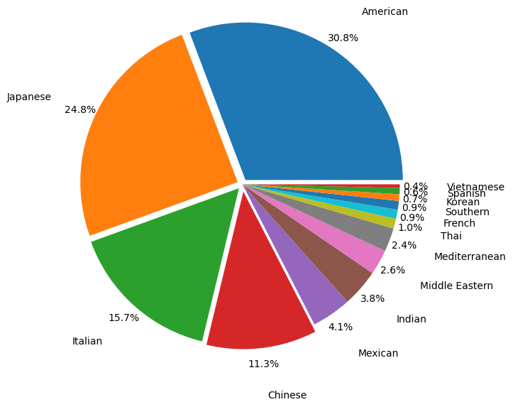

```python
# this variable is categorical, so we can use a pie chart to determine the top cuisines ordered


# 1 - look for unique labels within the cuisine_type column and count them
label_counts = df['cuisine_type'].value_counts()

# 2 - add the labels to a list that we can use for labeling the pie chart
unique_labels = label_counts.index.tolist()

# 3 - create pie chart and add percentages with only one decimal place and labels as well as adjust size for readability
plt.pie(df.cuisine_type.value_counts(), autopct='%.1f%%', radius = 1.5, pctdistance=1.1, labeldistance=1.3,
        labels=unique_labels, explode = (0.05, 0.05, 0.05, 0.07, 0, 0, 0, 0, 0, 0, 0, 0, 0, 0) )

# 4 - display pie chart
plt.show()
```

#### Observations:

The pie plot below shows that the top four cuisines ordered are:

- American (30.8%)
- Japanese (24.8%)
- Italian (15.7%)
- Chinese (11.3%)

### rating

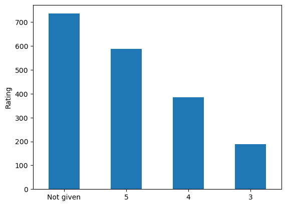

```python
# 1 - generate the bar plot
df.rating.value_counts().plot(kind='bar', rot = 0)

# 2 - label the y-axis
plt.ylabel('Rating')

# 3 - show the bar plot
plt.show()
```

### cost_of_the_order

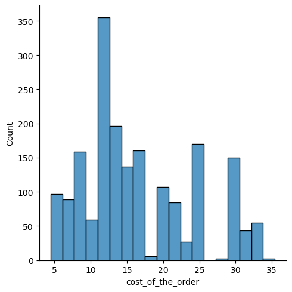

```python
#1 - generate the distribution plot
sns.displot(x='cost_of_the_order', data = df)

#2 - display the plot
plt.show()
```

### restaurant_name

```python
df['restaurant_name'].describe()
```

```
count            1898
unique            178
top       Shake Shack
freq              219
Name: restaurant_name, dtype: object
```

#### Observations:

The variable restaurant_name is categorical. 178 restaurants have received orders through the app, and the most popular restaurant is Shake Shack with 219 orders.

### day_of_the_week

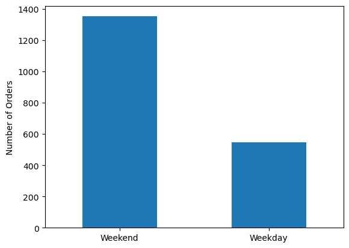

```python
# 1 - generate the bar plot
df.day_of_the_week.value_counts().plot(kind='bar', rot = 0)

# 2 - label the y-axis
plt.ylabel('Number of Orders')

# 3 - show the bar plot
plt.show()
```

#### Observations:

The variable is categorical. The bar plot shows that there are more orders placed on the weekends than weekdays.

### food_preparation_time

```python
df['food_preparation_time'].describe()
```

```
count    1898.000000
mean       27.371970
std         4.632481
min        20.000000
25%        23.000000
50%        27.000000
75%        31.000000
max        35.000000
Name: food_preparation_time, dtype: float64
```

#### Observations:

The variable is continuous and numerical. The quickest food prep time was 20 minutes, the longest was 35 minutes, and the IQR is 8 minutes.

### delivery_time

```python
df['delivery_time'].describe()
```

```
count    1898.000000
mean       24.161749
std         4.972637
min        15.000000
25%        20.000000
50%        25.000000
75%        28.000000
max        33.000000
Name: delivery_time, dtype: float64
```

#### Observations:

This variable is continuous and numerical. The calculations tell us that the quickest delivery time was 15 minutes, and the longest was 33 minutes. The IQR is 8 minutes.

### customer_id

```python
customer_id_counts = df['customer_id'].value_counts()
customer_id_counts.describe()
```

```
count    1200.000000
mean        1.581667
std         1.090560
min         1.000000
25%         1.000000
50%         1.000000
75%         2.000000
max        13.000000
Name: customer_id, dtype: float64
```

#### Observations:

- The top customer placed 13 orders.
- On average, customers placed 1.58 orders.

### **Question 7**: Which are the top 5 restaurants in terms of the number of orders received? [1 mark]

```python
# this code finds the unique restaurant names,
# counts how many times each restaurant name appears,
# and stores the results in a variable in descending order


restaurant_counts = df['restaurant_name'].value_counts()
restaurant_counts.head()
```

```
Shake Shack                  219
The Meatball Shop            132
Blue Ribbon Sushi            119
Blue Ribbon Fried Chicken     96
Parm                          68
Name: restaurant_name, dtype: int64
```

#### Observations:

According to this list, the top five restaurants in the data are:

1. Shake Shack
2. The Meatball Shop
3. Blue Ribbon Sushi
4. Blue Ribbon Fried Chicken
5. Parm

### Find the cuisine_type for the top five restaurants

```python
#Shake Shack
shake_shack_cuisine = df[df['restaurant_name'] == 'Shake Shack' ]
shake_shack_cuisine.head(1)
```

|  | order_id | customer_id | restaurant_name | cuisine_type | cost_of_the_order | day_of_the_week | rating | food_preparation_time | delivery_time |
| --- | --- | --- | --- | --- | --- | --- | --- | --- | --- |
| 15 | 1477414 | 66222 | Shake Shack | American | 16.2 | Weekend | 5 | 33 | 25 |

```python
#The Meatball Shop
the_meatball_shop_cuisine = df[df['restaurant_name'] == 'The Meatball Shop']
the_meatball_shop_cuisine.head(1)
```

|  | order_id | customer_id | restaurant_name | cuisine_type | cost_of_the_order | day_of_the_week | rating | food_preparation_time | delivery_time |
| --- | --- | --- | --- | --- | --- | --- | --- | --- | --- |
| 6 | 1477894 | 157711 | The Meatball Shop | Italian | 6.07 | Weekend | Not given | 28 | 21 |

```python
#Blue Ribbon Sushi
blue_ribbon_sushi_cuisine = df[df['restaurant_name'] == 'Blue Ribbon Sushi']
blue_ribbon_sushi_cuisine.head(1)
```

|  | order_id | customer_id | restaurant_name | cuisine_type | cost_of_the_order | day_of_the_week | rating | food_preparation_time | delivery_time |
| --- | --- | --- | --- | --- | --- | --- | --- | --- | --- |
| 19 | 1477354 | 67487 | Blue Ribbon Sushi | Japanese | 16.2 | Weekend | 4 | 35 | 26 |

```python
#Blue Ribbon Fried Chicken
blue_ribbon_fried_chicken_cuisine = df[df['restaurant_name'] == 'Blue Ribbon Fried Chicken']
blue_ribbon_fried_chicken_cuisine.head(1)
```

|  | order_id | customer_id | restaurant_name | cuisine_type | cost_of_the_order | day_of_the_week | rating | food_preparation_time | delivery_time |
| --- | --- | --- | --- | --- | --- | --- | --- | --- | --- |
| 3 | 1477334 | 106968 | Blue Ribbon Fried Chicken | American | 29.2 | Weekend | 3 | 25 | 15 |

```python
#Parm
parm_cuisine = df[df['restaurant_name'] == 'Parm']
parm_cuisine.head(1)
```

|  | order_id | customer_id | restaurant_name | cuisine_type | cost_of_the_order | day_of_the_week | rating | food_preparation_time | delivery_time |
| --- | --- | --- | --- | --- | --- | --- | --- | --- | --- |
| 34 | 1478244 | 181782 | Parm | Italian | 29.1 | Weekend | 5 | 30 | 26 |

#### Observations:

The top five most popular restaurants and their associated cuisine types are:

1. Shake Shack = American.
2. The Meatball Shop = Italian
3. Blue Ribbon Sushi = Japanese
4. Blue Ribbon Fried Chicken = American
5. Parm = Italian

### **Question 8**: Which is the most popular cuisine on weekends? [1 mark]

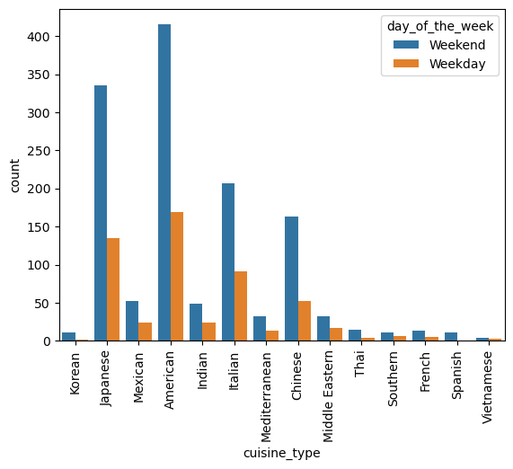

```python
# countplot can be used for the cuisine_type and day_of_the_week

# 1 - create the count plot to view cuisine type ordered based on the weekday
cuisine_weekday_plot = sns.countplot(data = df, x = 'cuisine_type', hue = 'day_of_the_week')

#2 - rotate the labels
cuisine_weekday_plot.set_xticklabels(cuisine_weekday_plot.get_xticklabels(), rotation=90, ha="center")

#3 - display the chart
plt.show()
```

#### Observations:

The most popular cuisine ordered on the weekends is American.

### **Question 9**: What percentage of the orders cost more than 20 dollars? [2 marks]

```python
# 1 - Find the number of orders over $20
orders_over_20 = df[df.cost_of_the_order > 20]

# 2 - Calculate the number of orders over $20 and save to a variable
total_orders_over_20 = len(orders_over_20.value_counts())

# 3 - Find the number of total orders
total_orders = len(df.order_id)

# 4 - Find the percentage
percentage = (total_orders_over_20/total_orders)*100

#5 - Get the percentage
print(percentage)
```

```
29.24130663856691
```

#### Observations:

The answer is 29.24% of orders cost more than $20.

### **Question 10**: What is the mean order delivery time? [1 mark]

```python
df['delivery_time'].mean()
```

```
24.161749209694417
```

#### Observations:

The mean is 24.16 minutes

### **Question 11:** The company has decided to give 20% discount vouchers to the top 3 most frequent customers. Find the IDs of these customers and the number of orders they placed. [1 mark]

```python
# 1 - Find unique customer_id and count
customer_id_counts = df['customer_id'].value_counts()

# 2 - view the top three customers
customer_id_counts.head(3)
```

```
52832    13
47440    10
83287     9
Name: customer_id, dtype: int64
```

#### Observations:

The top three customer ids are:

1. 52832 with 13 orders
2. 47440 with 10 orders
3. 83287 with 9 orders

### **Question 12**: Perform a multivariate analysis to explore relationships between the important variables in the dataset. (It is a good idea to explore relations between numerical variables as well as relations between numerical and categorical variables) [10 marks]

### cost_of_the_order and cuisine_type

```python
# 1 - look at the cuisine type in respect to the cost of the order and find the min, max, mean, and standard deviation.

df.groupby('cuisine_type').agg({'cost_of_the_order' : ['min', 'max', 'mean', 'std']})
```

| cuisine_type | cost_of_the_order min | cost_of_the_order max | cost_of_the_order mean | cost_of_the_order std |
| --- | --- | --- | --- | --- |
| American | 4.71 | 33.18 | 16.319829 | 7.462290 |
| Chinese | 4.75 | 34.19 | 16.305209 | 7.631503 |
| French | 11.98 | 29.25 | 19.793889 | 6.508990 |
| Indian | 5.34 | 33.03 | 16.919726 | 7.897493 |
| Italian | 5.05 | 33.03 | 16.418691 | 7.268831 |
| Japanese | 4.47 | 33.37 | 16.304532 | 7.422722 |
| Korean | 5.77 | 30.75 | 14.001538 | 7.563540 |
| Mediterranean | 5.67 | 35.41 | 15.474783 | 7.604720 |
| Mexican | 4.85 | 33.32 | 16.933117 | 7.555108 |
| Middle Eastern | 5.77 | 32.93 | 18.820612 | 8.086499 |
| Southern | 7.38 | 31.43 | 19.300588 | 7.966032 |
| Spanish | 12.13 | 29.10 | 18.994167 | 6.658207 |
| Thai | 6.69 | 32.93 | 19.207895 | 7.579149 |
| Vietnamese | 6.01 | 22.26 | 12.882857 | 5.319623 |

#### Observations:

- French cuisine has the highest mean order total of 19.79.
- Mediterranean cuisine has the highest order total of 35.41.
- The cheapest orders placed were for American (4.71), Japanese (4.47), Chinese (4.75), Mexican (4.85), and Italian (5.05). American, Japanese, Chinese, and Italian are the most popular cuisines ordered (based on previous analysis).

### cuisine_type and delivery_time

```python
df.groupby('cuisine_type').agg({'delivery_time' : ['min', 'max', 'mean', 'std']})
```

| cuisine_type | delivery_time min | delivery_time max | delivery_time mean | delivery_time std |
| --- | --- | --- | --- | --- |
| American | 15 | 33 | 24.193493 | 4.831844 |
| Chinese | 15 | 33 | 23.855814 | 4.966491 |
| French | 17 | 29 | 25.333333 | 3.741657 |
| Indian | 15 | 32 | 24.082192 | 5.054573 |
| Italian | 15 | 33 | 24.567114 | 5.179329 |
| Japanese | 15 | 33 | 24.131915 | 4.987366 |
| Korean | 16 | 26 | 20.923077 | 4.030334 |
| Mediterranean | 15 | 33 | 23.586957 | 5.422489 |
| Mexican | 16 | 33 | 24.389610 | 4.559997 |
| Middle Eastern | 15 | 33 | 24.081633 | 5.663615 |
| Southern | 15 | 33 | 23.823529 | 5.960655 |
| Spanish | 17 | 30 | 23.416667 | 4.813963 |
| Thai | 15 | 32 | 23.157895 | 4.991806 |
| Vietnamese | 19 | 31 | 26.142857 | 3.891382 |

#### Observations:

- The longest delivery time was 33 minutes, and this was the case for many of the cuisine types.
- The fastest delivery time was 15 minutes, and this was the case for many of the cuisine types.
- Vietnamese has the largest minimum delivery time of 19 minutes.

### all numerical values

```python
df.corr(numeric_only = True)
```

|  | order_id | customer_id | cost_of_the_order | food_preparation_time | delivery_time |
| --- | --- | --- | --- | --- | --- |
| order_id | 1.000000 | -0.013960 | 0.021171 | -0.007026 | 0.009690 |
| customer_id | -0.013960 | 1.000000 | -0.001322 | -0.030330 | -0.009885 |
| cost_of_the_order | 0.021171 | -0.001322 | 1.000000 | 0.041527 | -0.029949 |
| food_preparation_time | -0.007026 | -0.030330 | 0.041527 | 1.000000 | 0.011094 |
| delivery_time | 0.009690 | -0.009885 | -0.029949 | 0.011094 | 1.000000 |

#### Observations:

The largest correlation is a positive correlation between food preparation time and cost of the order; however, the correlation is very small (0.04).

### **Question 13:** The company wants to provide a promotional offer in the advertisement of the restaurants. The condition to get the offer is that the restaurants must have a rating count of more than 50 and the average rating should be greater than 4. Find the restaurants fulfilling the criteria to get the promotional offer. [3 marks]

```python
# 1 - make a copy of dataframe to analyze ratings

rating_df = df.copy()

# 2 - change the type of df.rating so that we can run calculations and convert
#     all 'Not given' to NaN so that column can be a float and is not counted towards the mean

rating_df['rating'] = rating_df['rating'].replace('Not given', np.nan)
rating_df['rating'] = rating_df['rating'].astype(float) #change type to float

# 3 - create new columns for each rating and set value equal to NaN if that rating does not exist
rating_df['rating_3'] = np.where(rating_df['rating'] == 3, 1, np.nan)
rating_df['rating_4'] = np.where(rating_df['rating'] == 4, 1, np.nan)
rating_df['rating_5'] = np.where(rating_df['rating'] == 5, 1, np.nan)

# 4 - create a new column that adds rating_3, rating_4, and rating_5
rating_df['rating_totals'] = np.where((rating_df['rating_3'] == 1) | (rating_df['rating_4'] == 1) | (rating_df['rating_5'] == 1), 1, np.nan)

# 5 - create two series so that totals can be viewed by restaurant name
rating_sum = rating_df.groupby('restaurant_name')['rating_totals'].sum() #sum total ratings for each restaurant
rating_mean = rating_df.groupby('restaurant_name')['rating'].mean() #calculate total mean for each restaurant


# 6 - create a new dataframe with restaurant name, rating totals, and rating mean
rating_total_df = pd.DataFrame({'restaurant_name': rating_sum.index, 'rating_totals': rating_sum.values, 'rating_mean':rating_mean.values})

# 7 - sort new dataframe by rating totals in descending order
sort_rating_total_df = rating_total_df.sort_values(by='rating_totals', ascending=False)


# 8 - display only the restaurants with at least 50 rating totals and a mean over 4.0
show_only_rating_counts_over_50 = sort_rating_total_df[(sort_rating_total_df['rating_totals'] > 50) & (sort_rating_total_df['rating_mean'] > 4.0)]

show_only_rating_counts_over_50
```

|  | restaurant_name | rating_totals | rating_mean |
| --- | --- | --- | --- |
| 136 | Shake Shack | 133.0 | 4.278195 |
| 153 | The Meatball Shop | 84.0 | 4.511905 |
| 21 | Blue Ribbon Sushi | 73.0 | 4.219178 |
| 20 | Blue Ribbon Fried Chicken | 64.0 | 4.328125 |

#### Observations:

The restaurants that have at least 50 ratings and a rating average of over 4 are:

- Shake Shack (133 total ratings and 4.28 average rating)
- The Meatball Shop (84 total ratings and 4.51 average rating)
- Blue Ribbon Sushi (73 total ratings and 4.22 average rating)
- Blue Ribbon Fried Chicken (64 total ratings and 4.33 average rating)

### Correlation between ratings and other variables

```python
rating_df.corr(numeric_only=True)
```

|  | order_id | customer_id | cost_of_the_order | rating | food_preparation_time | delivery_time | rating_3 | rating_4 | rating_5 | rating_totals |
| --- | --- | --- | --- | --- | --- | --- | --- | --- | --- | --- |
| order_id | 1.000000 | -0.013960 | 0.021171 | 0.006308 | -0.007026 | 0.009690 | NaN | NaN | NaN | NaN |
| customer_id | -0.013960 | 1.000000 | -0.001322 | 0.007753 | -0.030330 | -0.009885 | NaN | NaN | NaN | NaN |
| cost_of_the_order | 0.021171 | -0.001322 | 1.000000 | 0.033983 | 0.041527 | -0.029949 | NaN | NaN | NaN | NaN |
| rating | 0.006308 | 0.007753 | 0.033983 | 1.000000 | -0.006083 | -0.009804 | NaN | NaN | NaN | NaN |
| food_preparation_time | -0.007026 | -0.030330 | 0.041527 | -0.006083 | 1.000000 | 0.011094 | NaN | NaN | NaN | NaN |
| delivery_time | 0.009690 | -0.009885 | -0.029949 | -0.009804 | 0.011094 | 1.000000 | NaN | NaN | NaN | NaN |
| rating_3 | NaN | NaN | NaN | NaN | NaN | NaN | NaN | NaN | NaN | NaN |
| rating_4 | NaN | NaN | NaN | NaN | NaN | NaN | NaN | NaN | NaN | NaN |
| rating_5 | NaN | NaN | NaN | NaN | NaN | NaN | NaN | NaN | NaN | NaN |
| rating_totals | NaN | NaN | NaN | NaN | NaN | NaN | NaN | NaN | NaN | NaN |

#### Observations:

- The variables rating and food_preparation_time have a very small negative correlation.
- The variables rating and delivery_time also have a very small negative correlation.
- The variables rating and cost_of_the_order have a very small positive correlation.

### **Question 14:** The company charges the restaurant 25% on the orders having cost greater than 20 dollars and 15% on the orders having cost greater than 5 dollars. Find the net revenue generated by the company across all orders. [3 marks]

```python
# 1 - calculate revenue based on cost of the order and add net revenue to a new column

df['net_revenue'] = df['cost_of_the_order'].map(lambda x: x*0.15 if 5 < x < 20 else (x*0.25 if  x > 20 else 0))

# 2 - display total sum of net_revenue column
df['net_revenue'].sum()
```

```
6166.303
```

#### Observations:

The net revenue is 6166.30 dollars.

### Analysis on Net_Revenue

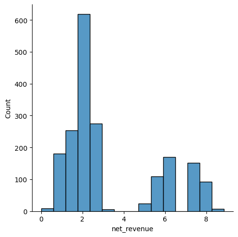

```python
# This plot shows the distribution for net revenue.

sns.displot(x='net_revenue', data = df)
```

#### Observations:

Running a univariate analysis on net_revenue, we see that most of the orders that generate revenue are bringing around 2 dollars per order.

### Looking at cuisine_type and net_revenue

```python
df.groupby('cuisine_type').agg({'net_revenue' : ['min', 'max', 'mean', 'std']})
```

| cuisine_type | net_revenue min | net_revenue max | net_revenue mean | net_revenue std |
| --- | --- | --- | --- | --- |
| American | 0.0000 | 8.2950 | 3.216223 | 2.284990 |
| Chinese | 0.0000 | 8.5475 | 3.209491 | 2.317150 |
| French | 1.7970 | 7.3125 | 4.232917 | 2.261936 |
| Indian | 0.8010 | 8.2575 | 3.383479 | 2.386812 |
| Italian | 0.7575 | 8.2575 | 3.244579 | 2.236102 |
| Japanese | 0.0000 | 8.3425 | 3.145201 | 2.269823 |
| Korean | 0.8655 | 7.6875 | 2.561769 | 2.227086 |
| Mediterranean | 0.8505 | 8.8525 | 2.963652 | 2.267591 |
| Mexican | 0.0000 | 8.3300 | 3.333675 | 2.336956 |
| Middle Eastern | 0.8655 | 8.2325 | 3.950071 | 2.551803 |
| Southern | 1.1070 | 7.8575 | 4.044324 | 2.598400 |
| Spanish | 1.8195 | 7.2750 | 3.936375 | 2.333930 |
| Thai | 1.0035 | 8.2325 | 4.108026 | 2.446569 |
| Vietnamese | 0.9015 | 5.5650 | 2.250429 | 1.545399 |

#### Observations:

- All cuisine type orders are generating net revenue except American, Chinese, Japanese, and Mexican. Interesting to note that American, Chinese, and Japanese cuisine types were also the top cuisines ordered (based on previous analysis).
- The highest average net revenue orders are for French (4.24), Thai (4.11), and Southern (4.04).
- The orders with the highest net revenues came from Mediterranean (8.85), Chinese (8.55), and Japanese (8.34)

### **Question 15:** The company wants to analyze the total time required to deliver the food. What percentage of orders take more than 60 minutes to get delivered from the time the order is placed? (The food has to be prepared and then delivered.) [2 marks]

```python
# 1 - create a new column for total time
df['total_time_for_order'] = df['food_preparation_time'] + df['delivery_time'] #displays total time in the new column

# 2 - Find the number of orders that take more than 60 minutes
orders_over_60_minutes = df[df.total_time_for_order > 60]

# 3 - Calculate the number of orders that take more than 60 mins and save to a variable
total_orders_over_60_minutes = len(orders_over_60_minutes.value_counts())

# 3 - Find the number of total orders
total_orders = len(df.order_id)

# 4 - Find the percentage
percentage = (total_orders_over_60_minutes/total_orders)*100

#5 - Get the percentage
print(percentage)
```

```
10.537407797681771
```

#### Observations:

The answer is 10.54% of orders take more than 60 minutes to prepare and deliver.

### **Question 16:** The company wants to analyze the delivery time of the orders on weekdays and weekends. How does the mean delivery time vary during weekdays and weekends? [2 marks]

```python
# 1 - find the delivery time mean based on the day of the week
day_of_the_week_mean = df.groupby('day_of_the_week')['delivery_time'].mean()

#2 - display the results
day_of_the_week_mean
```

```
day_of_the_week
Weekday    28.340037
Weekend    22.470022
Name: delivery_time, dtype: float64
```

#### Observations:

The weekday mean is higher than weekend mean by 5.87 minutes.

### Recommendations:

- To increase net revenue, it is recommended that FoodHub look into ways to incentivize customers to spend more on orders placed for American, Chinese, and Japanese cuisines so that these three popular cuisines generate more net revenue.
- It is recommended that FoodHub research ways to incentivize customers to leave a rating on their order so that more data is available for future analysis and to place an order during the weekdays (in addition to placing orders on the weekends) to boost weekday orders. As well, it is recommended that FoodHub research ways to convert customers that place one or two orders to returning customers.